# R Notebook

# Q3 題目

請根據上課所提到的 **kid_iq dataset**，建構一迴歸模型探索變數的非線性關係

(a)請探討 mom.iq 與依變數的 U 型關係，寫下迴歸的模型，並利用上課的 R 套件執行迴歸分析

(b)請說明你會如何檢驗 U 型關係的步驟，並搭配 R 套件驗證 U 型關係是否成立

(c)如若要探討**媽媽高中學歷是否會影響 mom.iq 對於依變數的關係**，請說明你會如何修改上述的迴歸模型，以及媽媽高中學歷會如何影響上述的 U 型關係

# 安裝套件以及載入資料

```r
# 載入套件
library(tidyverse)
library(ggplot2)
```

```r
# 載入 `kid_iq` 資料集
kid_iq <- read.csv("kid_iq.csv")
head(kid_iq)
```

|  | kid.score | mom.hs | mom.iq | mom.work | mom.age |
| --- | --- | --- | --- | --- | --- |
| 1 | 65 | 1 | 121.11753 | 4 | 27 |
| 2 | 98 | 1 | 89.36188 | 4 | 25 |
| 3 | 85 | 1 | 115.44316 | 4 | 27 |
| 4 | 83 | 1 | 99.44964 | 3 | 25 |
| 5 | 115 | 1 | 92.74571 | 4 | 27 |
| 6 | 98 | 0 | 107.90184 | 1 | 18 |

# 建立二次迴歸模型

建構迴歸模型探討 mom.iq 與依變數 kid_score 的 U 型關係，建立二次迴歸模型：

$y=a+b1⋅mom.iq+b2⋅mom.iq2$

```r
# 建構二次項的迴歸模型
model_u <- lm(kid.score ~ mom.iq + I(mom.iq^2), data = kid_iq)
summary(model_u)
```

```
Call:
lm(formula = kid.score ~ mom.iq + I(mom.iq^2), data = kid_iq)

Residuals:
    Min      1Q  Median      3Q     Max
-54.824 -11.640   2.883  11.372  50.813

Coefficients:
              Estimate Std. Error t value Pr(>|t|)
(Intercept) -99.033675  37.301385  -2.655 0.008226 **
mom.iq        3.076800   0.730291   4.213 3.07e-05 ***
I(mom.iq^2)  -0.011917   0.003517  -3.389 0.000767 ***
---
Signif. codes:  0 ‘***’ 0.001 ‘**’ 0.01 ‘*’ 0.05 ‘.’ 0.1 ‘ ’ 1

Residual standard error: 18.05 on 431 degrees of freedom
Multiple R-squared:  0.2217,    Adjusted R-squared:  0.2181
F-statistic: 61.38 on 2 and 431 DF,  p-value: < 2.2e-16
```

# 驗證 U 型關係是否成立

## 分析 Coefficients

```
Coefficients:
              Estimate Std. Error t value Pr(>|t|)
(Intercept) -99.033675  37.301385  -2.655 0.008226 **
mom.iq        3.076800   0.730291   4.213 3.07e-05 ***
I(mom.iq^2)  -0.011917   0.003517  -3.389 0.000767 ***
```

分析：

1. t-value 中顯示 mom.iq^2 與 mom.iq 具有統計意義顯著性。
2. 二次項係數（mom.iq^2）為負，顯示存在倒 U 關係
3. mom.iq 對 kid.score 有顯著的線性和非線性影響

## 視覺化

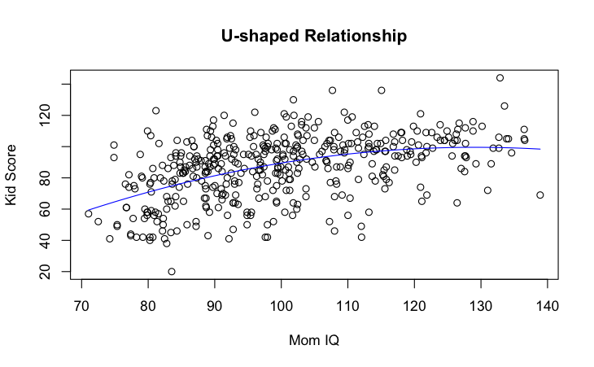

```r
# 繪製 mom.iq 與 kid.score 的散點圖與迴歸曲線
plot(kid_iq$mom.iq, kid_iq$kid.score, main = "U-shaped Relationship",
     xlab = "Mom IQ", ylab = "Kid Score")
curve(predict(model_u, newdata = data.frame(mom.iq = x)), add = TRUE, col = "blue")
```

## 一次微分視覺化

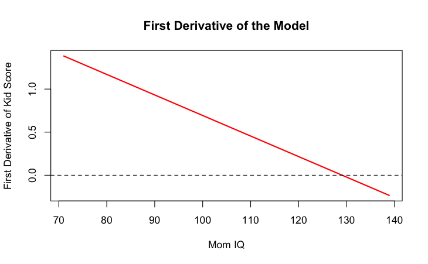

```r
# 提取模型係數
b1 <- coef(model_u)["mom.iq"]
b2 <- coef(model_u)["I(mom.iq^2)"]

# 定義一階導數的函數
first_derivative <- function(x) {
  b1 + 2 * b2 * x
}

# 繪製一階導數曲線（紅色線）
curve(first_derivative(x), from = min(kid_iq$mom.iq), to = max(kid_iq$mom.iq),
      main = "First Derivative of the Model",
      xlab = "Mom IQ", ylab = "First Derivative of Kid Score", col = "red", lty = 1, lwd = 2)

# 在 y 軸畫出 0 的水平線
abline(h = 0, col = "black", lty = 2)
```

從模型的散布圖以及一階微分的視覺化來看，可以確定該模型是倒 U 型關係。

## 小結

係數的顯著性以及視覺化的結果，證實了 mom.iq 與 kid.score 之間的**倒 U 型關係在統計上顯著。**

# 加入媽媽高中學歷

## 建立迴歸模型

將媽媽的高中學歷（mom.hs）加入模型，並與 mom.iq 和二次項交互作用，來探討高中學歷是否影響 U 型關係：

$y=a+b1⋅mom.iq+b2⋅mom.iq2+b3⋅mom.hs+b4⋅(mom.iq×mom.hs)+b5⋅(mom.iq2×mom.hs)$

```r
# mom.iq:mom.hs 和 I(mom.iq^2):mom.hs 表示 mom.hs 的交互作用項，
# 用來檢驗高中學歷是否改變 mom.iq 和二次項對依變數的影響。

model_interaction <- lm(kid.score ~ mom.iq + I(mom.iq^2) + mom.hs + mom.iq:mom.hs + I(mom.iq^2):mom.hs, data = kid_iq)

summary(model_interaction)
```

```
Call:
lm(formula = kid.score ~ mom.iq + I(mom.iq^2) + mom.hs + mom.iq:mom.hs +
    I(mom.iq^2):mom.hs, data = kid_iq)

Residuals:
    Min      1Q  Median      3Q     Max
-53.466 -10.085   2.655  11.352  46.517

Coefficients:
                     Estimate Std. Error t value Pr(>|t|)
(Intercept)        -1.237e+02  1.000e+02  -1.237    0.217
mom.iq              3.334e+00  2.093e+00   1.593    0.112
I(mom.iq^2)        -1.221e-02  1.078e-02  -1.133    0.258
mom.hs              8.129e+01  1.093e+02   0.743    0.458
mom.iq:mom.hs      -1.253e+00  2.259e+00  -0.554    0.580
I(mom.iq^2):mom.hs  4.623e-03  1.151e-02   0.402    0.688

Residual standard error: 17.91 on 428 degrees of freedom
Multiple R-squared:  0.2387,    Adjusted R-squared:  0.2298
F-statistic: 26.84 on 5 and 428 DF,  p-value: < 2.2e-16
```

分析：

1. 所有係數**均未達到統計顯著性。**
2. “I(mom.iq^2)” 與 “I(mom.iq^2):mom.hs” 觀察:
   1. “I(mom.iq^2)” 為 -1.221e-02（<0）
   2. “I(mom.iq^2):mom.hs” 顯示加入 “mom.hs” 項目後係數為 4.623e-03 (>0)
3. “mom.hs” 項目對於 “mom.iq” 跟 “kid.score” 之間的關係**有調節效果，但統計上不顯著**。

[figure not shown]

```r
# 生成樣本數據
set.seed(42)
mom.hs <- runif(100, 8, 16)
mom.iq <- mom.hs * 5 + rnorm(100, mean = 0, sd = 10)

# 繪製散佈圖
plot(mom.hs, mom.iq, main = "Scatter Plot of mom.hs vs mom.iq",
     xlab = "mom.hs", ylab = "mom.iq", pch = 19)

# 添加趨勢線
model <- lm(mom.iq ~ mom.hs)
abline(model, col = "red", lwd = 2)
```

計算兩個變數的相關係數：

```r
# 計算相關係數
correlation <- cor(mom.hs, mom.iq)
print(paste("Correlation: ", round(correlation, 3)))
```

```
[1] "Correlation:  0.824"
```

## 視覺化

為不同的 mom.hs 分組繪製二次迴歸曲線

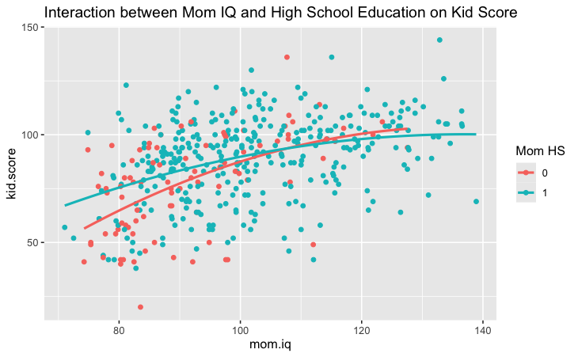

```r
ggplot(kid_iq, aes(x = mom.iq, y = kid.score, color = factor(mom.hs))) +
  geom_point() +
  stat_smooth(method = "lm", formula = y ~ poly(x, 2), se = FALSE) +
  labs(color = "Mom HS") +
  ggtitle("Interaction between Mom IQ and High School Education on Kid Score")
```

```r
# 為不同的 mom.hs 分組繪製二次迴歸曲線
# formula = y ~ poly(x, 2) 指定二次多項式模型，以便捕捉可能的非線性關係
```

## 一次微分視覺化

$d(y)/d(mom.iq)=b1+2b2⋅mom.iq+b4⋅mom.hs+2b5⋅mom.iq⋅mom.hs$

```r
# 提取模型係數
coefficients <- coef(model_interaction)
b1 <- coefficients["mom.iq"]
b2 <- coefficients["I(mom.iq^2)"]
b3 <- coefficients["mom.hs"]
b4 <- coefficients["mom.iq:mom.hs"]
b5 <- coefficients["I(mom.iq^2):mom.hs"]

# 定義一階導數的函數，針對不同的 mom.hs 狀態
first_derivative_hs0 <- function(x) {
  b1 + 2 * b2 * x
}

first_derivative_hs1 <- function(x) {
  (b1 + b4) + 2 * (b2 + b5) * x
}

# 繪製一階導數的圖，顯示 mom.hs = 0 和 mom.hs = 1 的情況
plot_range <- seq(min(kid_iq$mom.iq), max(kid_iq$mom.iq), length.out = 100)

# 繪製圖形
plot(plot_range, first_derivative_hs0(plot_range), type = "l", col = "red", lty = 1, lwd = 2,
     main = "First Derivative of the Model with Interaction",
     xlab = "Mom IQ", ylab = "First Derivative of Kid Score")

lines(plot_range, first_derivative_hs1(plot_range), col = "blue", lty = 2, lwd = 2)
```

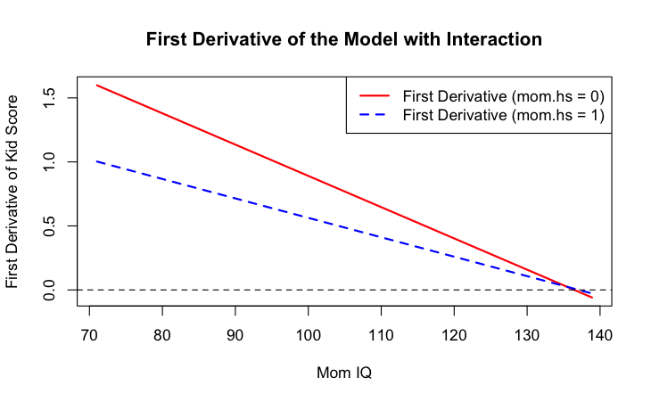

```r
# 在 y 軸畫出 0 的水平線
abline(h = 0, col = "black", lty = 2)

# 添加圖例
legend("topright", legend = c("First Derivative (mom.hs = 0)", "First Derivative (mom.hs = 1)"),
       col = c("red", "blue"), lty = c(1, 2), lwd = 2)
```

分析：

1. 從頓模型的一階導數視覺化結果看來，隨著 mom.iq 變大，一階導數的數值變化是**從正值到負值**，顯示無論是否「媽媽學歷」，**模型結果都呈現倒 U 型**。
2. 而 “mom.hs” = 0 的一階導數變化比起 “mom.hs” = 1 數值變化較大，有陡峭的倒 U 形狀。（但統計上不顯著）

## 小結

將媽媽的高中學歷（mom.hs）加入模型後，並與 mom.iq 和二次項交互作用，雖然模型顯示 mom.hs 具有交互作用，在視覺化上具有倒 U 關係，但統計上係數均 **未達到顯著性**，因此不能說模型具有倒 U 關係。